# Tugas Individu Kuliah MPDW

Raymond Edbert

2026-08-31

# Library

```r
library(readxl)
library(dplyr)
```

```r
library(ggplot2)
library(psych)
library(GGally)
library(corrplot)
library(TTR)
library(forecast)
library(lmtest)
```

# Data Yang Digunakan

```r
IPMAceh <- read_excel("C:\\Users\\bagan\\Downloads\\Book1.xlsx")
IPMAceh
```

```
## # A tibble: 15 × 2
##    Tahun   IPM
##    <dbl> <dbl>
##  1  2010  67.1
##  2  2011  67.4
##  3  2012  67.8
##  4  2013  68.3
##  5  2014  68.8
##  6  2015  69.4
##  7  2016  70
##  8  2017  70.6
##  9  2018  71.2
## 10  2019  71.9
## 11  2020  72.0
## 12  2021  72.2
## 13  2022  72.8
## 14  2023  73.4
## 15  2024  74.3
```

# Persamaan Model Linear

```r
model <- lm(IPM ~ Tahun, data = IPMAceh)

summary(model)
```

```
##
## Call:
## lm(formula = IPM ~ Tahun, data = IPMAceh)
##
## Residuals:
##      Min       1Q   Median       3Q      Max
## -0.33710 -0.14224 -0.01845  0.13871  0.39912
##
## Coefficients:
##               Estimate Std. Error t value Pr(>|t|)
## (Intercept) -954.36744   24.83785  -38.42 9.00e-15 ***
## Tahun          0.50811    0.01231   41.26 3.59e-15 ***
## ---
## Signif. codes:  0 '***' 0.001 '**' 0.01 '*' 0.05 '.' 0.1 ' ' 1
##
## Residual standard error: 0.2061 on 13 degrees of freedom
## Multiple R-squared:  0.9924, Adjusted R-squared:  0.9918
## F-statistic:  1703 on 1 and 13 DF,  p-value: 3.59e-15
```

$$\hat{Y}_t = \hat{\beta}_0 + \hat{\beta}_1 X_t$$

$$\widehat{IPM}_t = -954.36744 + 0.50811\,Tahun_t$$
Artinya setiap tahun berthambah sebanyak 0.50811 Satuan

# Diagnostik

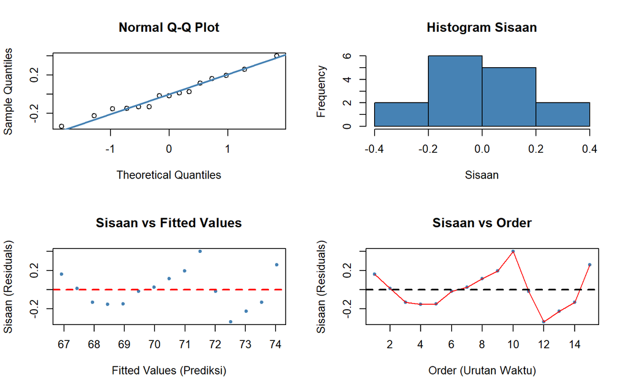

```r
sisaan <- residuals(model)
fitValue <- predict(model)

par(mfrow = c(2, 2))

# Plot 1: QQ Plot (Mengecek asumsi normalitas)
qqnorm(sisaan, main = "Normal Q-Q Plot")
qqline(sisaan, col = "steelblue", lwd = 2)

# Plot 2: Histogram (Mengecek asumsi normalitas)
hist(sisaan, col = "steelblue", main = "Histogram Sisaan", xlab = "Sisaan")

# Plot 3: Sisaan vs Fitted Values (Mengecek asumsi homoskedastisitas)
plot(fitValue, sisaan,
     col = "steelblue",
     pch = 20,
     xlab = "Fitted Values (Prediksi)",
     ylab = "Sisaan (Residuals)",
     main = "Sisaan vs Fitted Values")
abline(h = 0, col = "red", lwd = 2, lty = 2)

# Plot 4: Sisaan vs Order (Mengecek asumsi autokorelasi)
plot(seq_along(sisaan), sisaan,
     col = "steelblue",
     pch = 20,
     xlab = "Order (Urutan Waktu)",
     ylab = "Sisaan (Residuals)",
     main = "Sisaan vs Order")
lines(seq_along(sisaan), sisaan, col = "red")
abline(h = 0, lwd = 2, lty = 2)
```

```r
par(mfrow = c(1, 1))
```

# Normalitas Sisaan

```r
shapiro.test(sisaan)
```

```
##
##  Shapiro-Wilk normality test
##
## data:  sisaan
## W = 0.976, p-value = 0.9349
```

```r
ks.test(sisaan, "pnorm", mean=mean(sisaan), sd=sd(sisaan))
```

```
##
##  Exact one-sample Kolmogorov-Smirnov test
##
## data:  sisaan
## D = 0.14901, p-value = 0.846
## alternative hypothesis: two-sided
```

H0: sisaan mengikuti sebaran normal  
H1: sisaan tidak mengikuti sebaran normal  
Berdasarkan uji formal, kedua uji normalitas menunjukkan hasil yang konsisten. Uji Shapiro-Wilk menghasilkan p-value = 0.9349 (> 0.05), sehingga gagal tolak H0. Sejalan dengan hal tersebut, uji Kolmogorov-Smirnov juga menghasilkan p-value = 0.846 (> 0.05), yang berarti gagal tolak H0. Dengan demikian, dapat disimpulkan bahwa sisaan (residuals) dari model telah memenuhi asumsi dan menyebar normal.

## AUTOKORELASI

```r
dwtest(model)
```

```
##
##  Durbin-Watson test
##
## data:  model
## DW = 1.0323, p-value = 0.007771
## alternative hypothesis: true autocorrelation is greater than 0
```

Berdasarkan uji durbin watson benar adanya autokorelasi, karena p-value < 0.05

# Penanganan autokorelasi dengan Cochran Orcutt

```r
cochrane_orcutt <- function(model, max_iter = 100, tol = 1e-6) {

  # Data dan residual awal
  y <- model.response(model.frame(model))
  X <- model.matrix(model)

  e <- residuals(model)

  # Estimasi rho awal
  rho <- sum(e[-1] * e[-length(e)]) /
         sum(e[-length(e)]^2)

  for (i in 1:max_iter) {

    rho_lama <- rho

    # Transformasi Cochrane-Orcutt
    y_trans <- y[-1] - rho * y[-length(y)]
    X_trans <- X[-1, ] - rho * X[-length(y), ]

    # Model hasil transformasi
    model_trans <- lm(y_trans ~ X_trans - 1)

    # Residual hasil transformasi
    e_trans <- residuals(model_trans)

    # Estimasi rho baru menggunakan residual model asli
    beta <- coef(model_trans)
    e_asli <- y - X %*% beta

    rho <- sum(e_asli[-1] * e_asli[-length(e_asli)]) /
           sum(e_asli[-length(e_asli)]^2)

    # Cek konvergensi
    if (abs(rho - rho_lama) < tol) {
      break
    }
  }

  # Model final
  y_trans <- y[-1] - rho * y[-length(y)]
  X_trans <- X[-1, ] - rho * X[-length(y), ]

  model_final <- lm(y_trans ~ X_trans - 1)

  list(
    rho = rho,
    iterasi = i,
    model = model_final
  )
}

hasil_CO <- cochrane_orcutt(model)
rho <- hasil_CO$rho

hasil_CO
```

```
## $rho
## [1] 0.4913008
##
## $iterasi
## [1] 9
##
## $model
##
## Call:
## lm(formula = y_trans ~ X_trans - 1)
##
## Coefficients:
## X_trans(Intercept)        X_transTahun
##          -992.1928              0.5268
```

# cek autokorelasi setelah penanganan

```r
dwtest(hasil_CO$model)
```

```
##
##  Durbin-Watson test
##
## data:  hasil_CO$model
## DW = 1.299, p-value = 0.03965
## alternative hypothesis: true autocorrelation is greater than 0
```

Hasil pengujian Durbin-Watson pada model setelah dilakukan penanganan dengan metode Cochrane-Orcutt menunjukkan nilai DW sebesar 1.299 dan p-value sebesar 0.03965. Karena nilai p-value < 0.05, maka H0 ditolak. Hal ini berarti pada taraf nyata 5%, masih terdapat cukup bukti yang menyatakan bahwa sisaan memiliki autokorelasi (positif). Dengan demikian, penanganan menggunakan metode Cochrane-Orcutt belum berhasil memulihkan asumsi non-autokorelasi pada model.

# Penanganan Autokorelasi Hildreth-Lu

```r
# Membuat fungsi Hildreth-Lu
hildreth.lu.func <- function(r, model){
  x <- model.matrix(model)[,-1]
  y <- model.response(model.frame(model))
  n <- length(y)
  t <- 2:n
  y <- y[t] - r*y[t-1]
  x <- x[t] - r*x[t-1]

  return(lm(y ~ x))
}

# Pencarian rho yang meminimumkan SSE
r <- c(seq(0.1, 0.9, by = 0.1))
tab <- data.frame("rho" = r, "SSE" = sapply(r, function(i){deviance(hildreth.lu.func(i, model))}))

# Menampilkan tabel rho dan SSE dengan 4 angka di belakang koma
round(tab, 4)
```

```
##   rho    SSE
## 1 0.1 0.4764
## 2 0.2 0.4447
## 3 0.3 0.4224
## 4 0.4 0.4092
## 5 0.5 0.4054
## 6 0.6 0.4109
## 7 0.7 0.4256
## 8 0.8 0.4496
## 9 0.9 0.4828
```

Pertama-tama akan dicari di mana kira-kira $\rho$ yang menghasilkan SSE minimum. Berdasarkan hasil iterasi di atas, terlihat bahwa nilai SSE menurun dan mencapai titik terendah pada $\rho = 0.5$ dengan nilai SSE sebesar 0.4054, lalu kembali meningkat setelahnya. Oleh karena itu, $\rho$ optimum diperkirakan berada di sekitar 0.5. Namun, hasil tersebut masih kurang teliti sehingga akan dicari kembali $\rho$ yang lebih presisi. Jarak antar $\rho$ yang dicari sebelumnya adalah 0.1, kali ini jarak antar $\rho$ yang digunakan adalah 0.001 dan dilakukan pencarian pada rentang yang lebih sempit, yaitu pada selang 0.4 sampai dengan 0.6

```r
# Rho optimal di sekitar 0.5
rOpt <- seq(0.4, 0.6, by = 0.001)

# Mencari SSE untuk masing-masing rho pada rentang baru
tabOpt <- data.frame("rho" = rOpt, "SSE" = sapply(rOpt, function(i){deviance(hildreth.lu.func(i, model))}))

# Menampilkan 6 nilai rho teratas yang menghasilkan SSE paling kecil
head(tabOpt[order(tabOpt$SSE), ])
```

```
##      rho       SSE
## 92 0.491 0.4053775
## 93 0.492 0.4053777
## 91 0.490 0.4053782
## 94 0.493 0.4053788
## 90 0.489 0.4053799
## 95 0.494 0.4053808
```

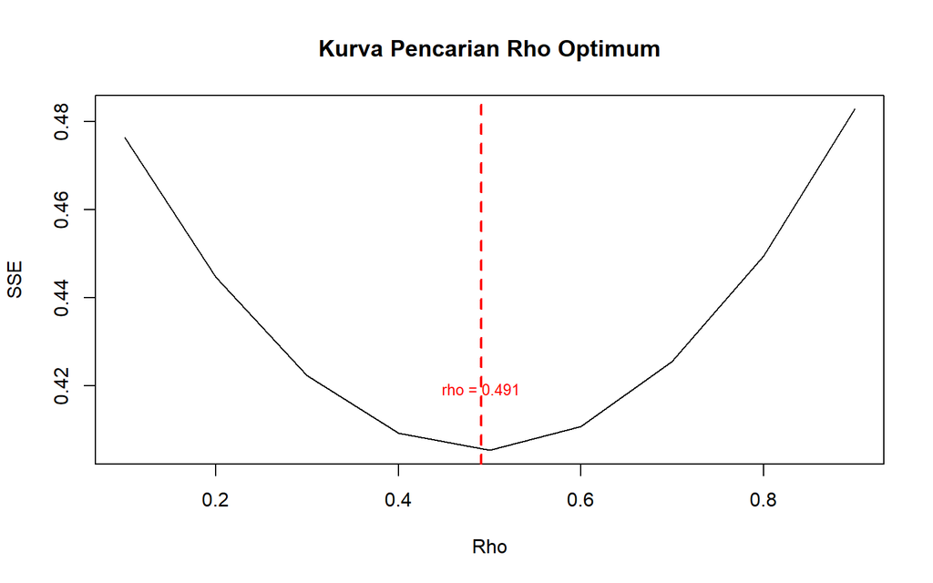

```r
# Mendapatkan nilai rho optimal dan SSE minimum secara otomatis
rho_optimum <- tabOpt[tabOpt$SSE == min(tabOpt$SSE), "rho"]
sse_minimum <- min(tabOpt$SSE)

# Grafik SSE optimum
par(mfrow = c(1,1))
plot(tab$rho, tab$SSE, type = "l", xlab = "Rho", ylab = "SSE",
     main = "Kurva Pencarian Rho Optimum")

# Membuat garis vertikal pada rho optimum
abline(v = rho_optimum, lty = 2, col = "red", lwd = 2)

# Menambahkan teks secara dinamis (posisi otomatis menyesuaikan)
text(x = rho_optimum, y = sse_minimum + 0.01,
     labels = paste("rho =", rho_optimum),
     col = "red", cex = 0.8, pos = 3)
```

Perhitungan yang dilakukan aplikasi R menunjukkan bahwa nilai $\rho$ optimum, yaitu saat SSE terkecil, terdapat pada nilai $\rho=0.491$. Hal tersebut juga ditunjukkan pada plot. Selanjutnya, model dapat didapatkan dengan mengevaluasi nilai $\rho$ ke dalam fungsi hildreth.lu.func, serta dilanjutkan dengan pengujian autokorelasi dengan uji Durbin-Watson. Namun, setelah pengecekan tersebut tidak lupa koefisien regresi tersebut digunakan untuk transformasi balik. Persamaan hasil transformasi itulah yang menjadi persamaan sesungguhnya

```r
# Model terbaik menggunakan rho optimum (0.491)
modelHL <- hildreth.lu.func(rho_optimum, model)
summary(modelHL)
```

```
##
## Call:
## lm(formula = y ~ x)
##
## Residuals:
##      Min       1Q   Median       3Q      Max
## -0.35862 -0.08272 -0.02045  0.10375  0.29050
##
## Coefficients:
##               Estimate Std. Error t value Pr(>|t|)
## (Intercept) -505.00958   24.59634  -20.53 1.03e-10 ***
## x              0.52683    0.02394   22.01 4.56e-11 ***
## ---
## Signif. codes:  0 '***' 0.001 '**' 0.01 '*' 0.05 '.' 0.1 ' ' 1
##
## Residual standard error: 0.1838 on 12 degrees of freedom
## Multiple R-squared:  0.9758, Adjusted R-squared:  0.9738
## F-statistic: 484.3 on 1 and 12 DF,  p-value: 4.557e-11
```

```r
# Transformasi Balik
cat("y = ", coef(modelHL)[1]/(1 - rho_optimum), " + ", coef(modelHL)[2], "x", sep = "")
```

```
## y = -992.1603 + 0.5268283x
```

Setelah dilakukan transformasi balik, didapatkan model dengan metode Hildreth-Lu sebagai berikut.
$$y=-992.1603+0.5268283x$$

## PEMERIKSAAN ULANG AUTOKORELASI

```r
dwtest(modelHL)
```

```
##
##  Durbin-Watson test
##
## data:  modelHL
## DW = 1.2989, p-value = 0.03963
## alternative hypothesis: true autocorrelation is greater than 0
```

“Hasil uji Durbin-Watson pada model setelah transformasi menunjukkan nilai DW sebesar 1.2989 dan p-value sebesar 0.03963. Karena nilai p-value < 0.05, maka H0 ditolak. Hal ini menunjukkan bahwa pada taraf nyata 5%, sudah cukup bukti untuk menyatakan bahwa masih terdapat masalah autokorelasi pada sisaan model tersebut.”

# Perbandingan Kedua Metode

```r
# Perbandingan Nilai SSE dan MSE
sseModelawal <- anova(model)$`Sum Sq`[-1]
sseModelCO <- anova(hasil_CO$model)$`Sum Sq`[-1]
sseModelHL <- anova(modelHL)$`Sum Sq`[-1]

# Mendapatkan jumlah observasi (n) dari model
n <- length(resid(model))

# Menghitung MSE
mseModelawal <- sseModelawal / n
mseModelCO <- sseModelCO / n
mseModelHL <- sseModelHL / n

# Membuat matriks perbandingan
akurasi <- matrix(c(sseModelawal, sseModelCO, sseModelHL,
                    mseModelawal, mseModelCO, mseModelHL),
                  nrow = 2, ncol = 3, byrow = TRUE)

# Memberikan penamaan pada kolom dan baris
colnames(akurasi) <- c("Model Awal", "Model Cochrane-Orcutt", "Model Hildreth-Lu")
row.names(akurasi) <- c("SSE", "MSE")

# Menampilkan tabel hasil perbandingan
akurasi
```

```
##     Model Awal Model Cochrane-Orcutt Model Hildreth-Lu
## SSE 0.55197012            0.40537743        0.40537747
## MSE 0.03679801            0.02702516        0.02702516
```

Berdasarkan hasil perbandingan akurasi pada tabel, penanganan autokorelasi menggunakan metode Cochrane-Orcutt maupun Hildreth-Lu terbukti mampu menurunkan galat model secara signifikan dibandingkan dengan Model Awal. Hal ini terlihat dari penurunan nilai SSE dari 0.5519 menjadi sekitar 0.4053, serta nilai MSE dari 0.0367 menjadi 0.0270.

Jika dibandingkan antara kedua metode penanganan tersebut, keduanya memberikan hasil yang hampir identik. Namun, Model Cochrane-Orcutt menghasilkan nilai SSE yang sangat sedikit lebih kecil (0.40537743) dibandingkan dengan Model Hildreth-Lu (0.40537747). Oleh karena itu, Model Cochrane-Orcutt dapat disimpulkan sebagai model yang relatif paling baik dan akurat di antara ketiga model tersebut karena memiliki tingkat kesalahan (error) yang paling minimum.

# Kesimpulan

Penerapan metode Cochrane-Orcutt dan Hildreth-Lu terbukti mampu meningkatkan akurasi model dengan menurunkan nilai galat (SSE turun dari 0.5519 menjadi 0.4053; MSE turun dari 0.0367 menjadi 0.0270). Kedua metode memberikan hasil akurasi yang nyaris identik. Namun, berdasarkan hasil uji Durbin-Watson, kedua metode tersebut sama-sama belum berhasil mengatasi masalah autokorelasi (p-value < 0.05). Oleh karena itu, model akhir ini belum sepenuhnya valid karena masih melanggar asumsi regresi, sehingga memerlukan metode penanganan lanjutan lainnya.